# Supervised Learning - Foundations Project: ReCell

**What is the distribution of devices offering greater than 8MP selfie cameras across brands?**

```python
df4 = used_device_df[used_device_df['selfie_camera_mp'] > 8]
df4['brand_name'].value_counts()
print('Distribution of devices offering greater than 8MP selfie cameras across brands:''\n',df4['brand_name'].value_counts())
```

```
Distribution of devices offering greater than 8MP selfie cameras across brands:
 Huawei        87
Vivo          78
Oppo          75
Xiaomi        63
Samsung       57
Honor         41
Others        34
LG            32
Motorola      26
Meizu         24
HTC           20
ZTE           20
Realme        18
OnePlus       18
Lenovo        14
Sony          14
Nokia         10
Asus           6
Infinix        4
Gionee         4
Coolpad        3
BlackBerry     2
Micromax       2
Panasonic      2
Acer           1
Name: brand_name, dtype: int64
```

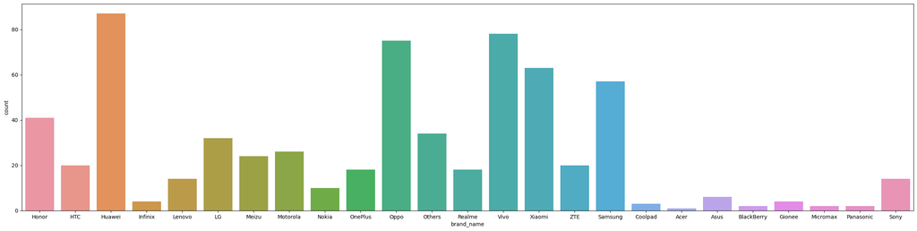

```python
# Distribution of devices offering greater than 8MP selfie cameras across brands
plt.figure(figsize=(30, 7))
sns.countplot(x='brand_name',data=df4)
```

As you can see Huawei top the list with 87 phone followed by Vivo with 78 phone with selfei camera mp more then 8 mp.Oppo,Xioami and Samsung also has 75,63 and 57 phones with selfei camera mp more then 8 mp.

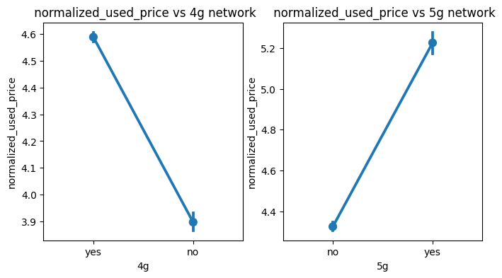

```python
# Analyzing normalized_used_price vs 4g and 5g network
fig, axes = plt.subplots(1, 2, figsize = (8,4))
sns.pointplot(ax=axes[0],x='4g',y='normalized_used_price',data=used_device_df);
axes[0].set_title(' normalized_used_price vs 4g network');
sns.pointplot(ax=axes[1],x='5g',y='normalized_used_price',data=used_device_df);
axes[1].set_title(' normalized_used_price vs 5g network');
```

As you can see normalized_used_price is heigher for phone with 4g about 4.6 euros comapred with phone does not have 4g about 3.9 euros.Similarly It is heigher for phone with 5g network about 5.2 euros comapred with phone does not have 5g about 4.3 euros.Price of a phone with 5g network is heigher then phone with 4g network.

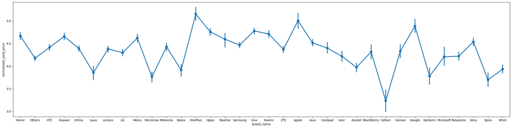

```python
# normlized_used_price vs brand_name of the phone
plt.figure(figsize=(30, 7))
sns.pointplot(x='brand_name',y='normalized_used_price',data=used_device_df)
```

As we can see from the above plot brand like Apple, One plus and Google has higher normlized price for used phone. Celkon brand has lowest value for the used phone.

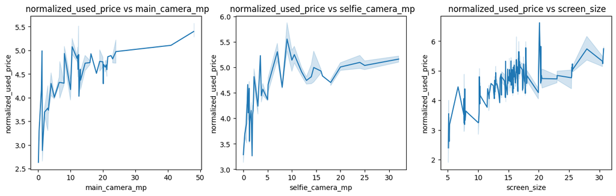

```python
# Analyzing normalized_used_price vs main_camera_mp,selfie_camera_mp and screen size
fig, axes = plt.subplots(1, 3, figsize = (15,4))
sns.lineplot(ax=axes[0],x='main_camera_mp',y='normalized_used_price',data=used_device_df);
axes[0].set_title(' normalized_used_price vs main_camera_mp');
sns.lineplot(ax=axes[1],x='selfie_camera_mp',y='normalized_used_price',data=used_device_df);
axes[1].set_title(' normalized_used_price vs selfie_camera_mp');
sns.lineplot(ax=axes[2],x='screen_size',y='normalized_used_price',data=used_device_df);
axes[2].set_title(' normalized_used_price vs screen_size');
```

As we can see from the plots normalized_used_price increase with increase in size of screen, main camera pixel and selfie camera pixel.

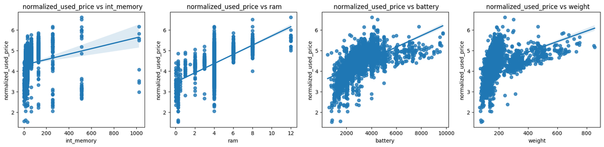

```python
# Analyzing normalized_used_price vs int_memory,ram,battery and weight
fig, axes = plt.subplots(1, 4, figsize = (20,4))
sns.regplot(ax=axes[0],x='int_memory',y='normalized_used_price',data=used_device_df);
axes[0].set_title(' normalized_used_price vs int_memory');
sns.regplot(ax=axes[1],x='ram',y='normalized_used_price',data=used_device_df);
axes[1].set_title(' normalized_used_price vs ram');
sns.regplot(ax=axes[2],x='battery',y='normalized_used_price',data=used_device_df);
axes[2].set_title(' normalized_used_price vs battery');
sns.regplot(ax=axes[3],x='weight',y='normalized_used_price',data=used_device_df);
axes[3].set_title(' normalized_used_price vs weight');
```

As per the above plot we can see that normalized value of used phone increases with the increase in internal memory,ram,battery and weight of the phone.

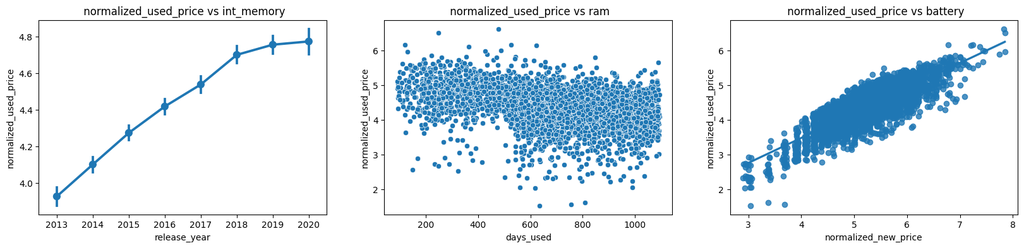

```python
# Analyzing normalized_used_price vs year released, days used and normalized_new_price
fig, axes = plt.subplots(1, 3, figsize = (20,4))
sns.pointplot(ax=axes[0],x='release_year',y='normalized_used_price',data=used_device_df);
axes[0].set_title(' normalized_used_price vs int_memory');
sns.scatterplot(ax=axes[1],x='days_used',y='normalized_used_price',data=used_device_df);
axes[1].set_title(' normalized_used_price vs ram');
sns.regplot(ax=axes[2],x='normalized_new_price',y='normalized_used_price',data=used_device_df);
axes[2].set_title(' normalized_used_price vs battery');
```

As per the plot we conclude that normalized_used_price increases with release year and new phone price. It is reduces with days_used increases.

```python
# Pairplot for the analysis between different features
sns.pairplot(used_device_df[['screen_size','main_camera_mp',
       'selfie_camera_mp', 'int_memory', 'ram', 'battery', 'weight',
       'release_year', 'days_used', 'normalized_used_price',
       'normalized_new_price']])
```

[output not shown]

```
Output hidden; open in https://colab.research.google.com to view.
```

## Data Preprocessing

- Missing value treatment
- Feature engineering
- Outlier detection and treatment
- Preparing data for modeling
- Any other preprocessing steps

# Missing value Treatment

```python
#Checking for null values in dataset
used_device_df.isna().sum()
```

```
brand_name                 0
os                         0
screen_size                0
4g                         0
5g                         0
main_camera_mp           179
selfie_camera_mp           2
int_memory                 4
ram                        4
battery                    6
weight                     7
release_year               0
days_used                  0
normalized_used_price      0
normalized_new_price       0
dtype: int64
```

```python
# We can use fillna for filling values with median for main_camera_mp
used_device_df['main_camera_mp'] = used_device_df['main_camera_mp'].fillna(used_device_df['main_camera_mp'].median())
#Checking for null values in dataset
used_device_df.isna().sum()
```

```
brand_name               0
os                       0
screen_size              0
4g                       0
5g                       0
main_camera_mp           0
selfie_camera_mp         2
int_memory               4
ram                      4
battery                  6
weight                   7
release_year             0
days_used                0
normalized_used_price    0
normalized_new_price     0
dtype: int64
```

```python
# We can fill out all remaining nan with mean of there dataset
used_device_df = used_device_df.fillna(used_device_df.mean())
```

```python
#Checking for null values in dataset
used_device_df.isna().sum()
```

```
brand_name               0
os                       0
screen_size              0
4g                       0
5g                       0
main_camera_mp           0
selfie_camera_mp         0
int_memory               0
ram                      0
battery                  0
weight                   0
release_year             0
days_used                0
normalized_used_price    0
normalized_new_price     0
dtype: int64
```

**Now There are no missing values in the dataset**

# Feature engineering

```python
# Using get_dummies to deal with categorical variables
used_device_df2 = pd.get_dummies(used_device_df, columns=['brand_name','os','4g','5g'], drop_first=True)
display(used_device_df2.columns)
display(used_device_df2.head())
```

```
Index(['screen_size', 'main_camera_mp', 'selfie_camera_mp', 'int_memory',
       'ram', 'battery', 'weight', 'release_year', 'days_used',
       'normalized_used_price', 'normalized_new_price', 'brand_name_Alcatel',
       'brand_name_Apple', 'brand_name_Asus', 'brand_name_BlackBerry',
       'brand_name_Celkon', 'brand_name_Coolpad', 'brand_name_Gionee',
       'brand_name_Google', 'brand_name_HTC', 'brand_name_Honor',
       'brand_name_Huawei', 'brand_name_Infinix', 'brand_name_Karbonn',
       'brand_name_LG', 'brand_name_Lava', 'brand_name_Lenovo',
       'brand_name_Meizu', 'brand_name_Micromax', 'brand_name_Microsoft',
       'brand_name_Motorola', 'brand_name_Nokia', 'brand_name_OnePlus',
       'brand_name_Oppo', 'brand_name_Others', 'brand_name_Panasonic',
       'brand_name_Realme', 'brand_name_Samsung', 'brand_name_Sony',
       'brand_name_Spice', 'brand_name_Vivo', 'brand_name_XOLO',
       'brand_name_Xiaomi', 'brand_name_ZTE', 'os_Others', 'os_Windows',
       'os_iOS', '4g_yes', '5g_yes'],
      dtype='object')
```

|  | screen_size | main_camera_mp | selfie_camera_mp | int_memory | ram | battery | weight | release_year | days_used | normalized_used_price | ... | brand_name_Spice | brand_name_Vivo | brand_name_XOLO | brand_name_Xiaomi | brand_name_ZTE | os_Others | os_Windows | os_iOS | 4g_yes | 5g_yes |
| --- | --- | --- | --- | --- | --- | --- | --- | --- | --- | --- | --- | --- | --- | --- | --- | --- | --- | --- | --- | --- | --- |
| 0 | 14.50 | 13.0 | 5.0 | 64.0 | 3.0 | 3020.0 | 146.0 | 2020 | 127 | 4.307572 | ... | 0 | 0 | 0 | 0 | 0 | 0 | 0 | 0 | 1 | 0 |
| 1 | 17.30 | 13.0 | 16.0 | 128.0 | 8.0 | 4300.0 | 213.0 | 2020 | 325 | 5.162097 | ... | 0 | 0 | 0 | 0 | 0 | 0 | 0 | 0 | 1 | 1 |
| 2 | 16.69 | 13.0 | 8.0 | 128.0 | 8.0 | 4200.0 | 213.0 | 2020 | 162 | 5.111084 | ... | 0 | 0 | 0 | 0 | 0 | 0 | 0 | 0 | 1 | 1 |
| 3 | 25.50 | 13.0 | 8.0 | 64.0 | 6.0 | 7250.0 | 480.0 | 2020 | 345 | 5.135387 | ... | 0 | 0 | 0 | 0 | 0 | 0 | 0 | 0 | 1 | 1 |
| 4 | 15.32 | 13.0 | 8.0 | 64.0 | 3.0 | 5000.0 | 185.0 | 2020 | 293 | 4.389995 | ... | 0 | 0 | 0 | 0 | 0 | 0 | 0 | 0 | 1 | 0 |

5 rows × 49 columns

```python
# We can compute the age of the phone so we don't have to use the year in the model
used_device_df2['no_years_release'] = 2021 - used_device_df2['release_year']
display(used_device_df2.head())
```

|  | screen_size | main_camera_mp | selfie_camera_mp | int_memory | ram | battery | weight | release_year | days_used | normalized_used_price | ... | brand_name_Vivo | brand_name_XOLO | brand_name_Xiaomi | brand_name_ZTE | os_Others | os_Windows | os_iOS | 4g_yes | 5g_yes | no_years_release |
| --- | --- | --- | --- | --- | --- | --- | --- | --- | --- | --- | --- | --- | --- | --- | --- | --- | --- | --- | --- | --- | --- |
| 0 | 14.50 | 13.0 | 5.0 | 64.0 | 3.0 | 3020.0 | 146.0 | 2020 | 127 | 4.307572 | ... | 0 | 0 | 0 | 0 | 0 | 0 | 0 | 1 | 0 | 1 |
| 1 | 17.30 | 13.0 | 16.0 | 128.0 | 8.0 | 4300.0 | 213.0 | 2020 | 325 | 5.162097 | ... | 0 | 0 | 0 | 0 | 0 | 0 | 0 | 1 | 1 | 1 |
| 2 | 16.69 | 13.0 | 8.0 | 128.0 | 8.0 | 4200.0 | 213.0 | 2020 | 162 | 5.111084 | ... | 0 | 0 | 0 | 0 | 0 | 0 | 0 | 1 | 1 | 1 |
| 3 | 25.50 | 13.0 | 8.0 | 64.0 | 6.0 | 7250.0 | 480.0 | 2020 | 345 | 5.135387 | ... | 0 | 0 | 0 | 0 | 0 | 0 | 0 | 1 | 1 | 1 |
| 4 | 15.32 | 13.0 | 8.0 | 64.0 | 3.0 | 5000.0 | 185.0 | 2020 | 293 | 4.389995 | ... | 0 | 0 | 0 | 0 | 0 | 0 | 0 | 1 | 0 | 1 |

5 rows × 50 columns

# Outlier detection and treatment

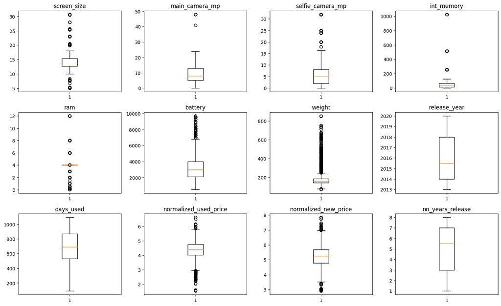

```python
# outlier detection using boxplot
# selecting the numerical columns of data and adding their names in a list
numeric_columns = ['screen_size', 'main_camera_mp', 'selfie_camera_mp', 'int_memory',
       'ram', 'battery', 'weight', 'release_year', 'days_used',
       'normalized_used_price', 'normalized_new_price','no_years_release']
plt.figure(figsize=(15, 12))

for i, variable in enumerate(numeric_columns):
    plt.subplot(4, 4, i + 1)
    plt.boxplot(used_device_df2[variable], whis=1.5)
    plt.tight_layout()
    plt.title(variable)

plt.show()
```

```python
# to find the 25th percentile and 75th percentile for the numerical columns.
Q1 = used_device_df2[numeric_columns].quantile(0.25)
Q3 = used_device_df2[numeric_columns].quantile(0.75)

IQR = Q3 - Q1                   #Inter Quantile Range (75th percentile - 25th percentile)

lower_whisker = Q1 - 1.5*IQR    #Finding lower and upper bounds for all values. All values outside these bounds are outliers
upper_whisker = Q3 + 1.5*IQR
```

```python
# Percentage of outliers in each column
((used_device_df2[numeric_columns] < lower_whisker) | (used_device_df2[numeric_columns] > upper_whisker)).sum()/used_device_df2.shape[0]*100
```

```
screen_size              13.028373
main_camera_mp            0.144760
selfie_camera_mp          6.398379
int_memory                3.995368
ram                      18.500290
battery                   2.229299
weight                   10.654314
release_year              0.000000
days_used                 0.000000
normalized_used_price     2.460915
normalized_new_price      1.910828
no_years_release          0.000000
dtype: float64
```

**We can see release_year,days_used and years_release does not have any outlier.All other columns which has outlier are seems to be possible values so I don't think we need to treat those outlier.**

## Model Building - Linear Regression

```python
# independent variables
X = used_device_df2.drop(["normalized_used_price",'release_year'], axis=1)
# dependent variable
y = used_device_df2[["normalized_used_price"]]
# this adds the constant term to the dataset
X = sm.add_constant(X)
```

```python
# Spliting data using train_test_split
X_train, X_test, y_train, y_test = train_test_split(
    X, y, test_size=0.30, random_state=1
)
```

```python
# Fitting the model
olsmod = sm.OLS(y_train, X_train)
olsres = olsmod.fit()
```

```python
# let's print the regression summary
print(olsres.summary())
```

```
                              OLS Regression Results
=================================================================================
Dep. Variable:     normalized_used_price   R-squared:                       0.845
Model:                               OLS   Adj. R-squared:                  0.842
Method:                    Least Squares   F-statistic:                     268.8
Date:                   Tue, 10 Oct 2023   Prob (F-statistic):               0.00
Time:                           01:39:30   Log-Likelihood:                 124.04
No. Observations:                   2417   AIC:                            -150.1
Df Residuals:                       2368   BIC:                             133.6
Df Model:                             48
Covariance Type:               nonrobust
=========================================================================================
                            coef    std err          t      P>|t|      [0.025      0.975]
-----------------------------------------------------------------------------------------
const                     1.3283      0.071     18.603      0.000       1.188       1.468
screen_size               0.0243      0.003      7.145      0.000       0.018       0.031
main_camera_mp            0.0203      0.001     13.807      0.000       0.017       0.023
selfie_camera_mp          0.0136      0.001     12.069      0.000       0.011       0.016
int_memory                0.0001   6.97e-05      1.526      0.127   -3.03e-05       0.000
ram                       0.0239      0.005      4.660      0.000       0.014       0.034
battery               -1.585e-05   7.27e-06     -2.181      0.029   -3.01e-05    -1.6e-06
weight                    0.0010      0.000      7.427      0.000       0.001       0.001
days_used              3.458e-05   3.09e-05      1.118      0.263    -2.6e-05    9.52e-05
normalized_new_price      0.4311      0.012     35.138      0.000       0.407       0.455
brand_name_Alcatel        0.0153      0.048      0.322      0.748      -0.078       0.109
brand_name_Apple         -0.0116      0.147     -0.079      0.937      -0.300       0.277
brand_name_Asus           0.0196      0.048      0.408      0.683      -0.074       0.113
brand_name_BlackBerry    -0.0294      0.070     -0.419      0.675      -0.167       0.108
brand_name_Celkon        -0.0421      0.066     -0.636      0.525      -0.172       0.088
brand_name_Coolpad        0.0403      0.073      0.553      0.580      -0.103       0.183
brand_name_Gionee         0.0454      0.058      0.787      0.431      -0.068       0.159
brand_name_Google        -0.0334      0.085     -0.394      0.693      -0.199       0.133
brand_name_HTC           -0.0115      0.048     -0.239      0.811      -0.106       0.083
brand_name_Honor          0.0245      0.049      0.499      0.618      -0.072       0.121
brand_name_Huawei        -0.0079      0.044     -0.178      0.859      -0.095       0.079
brand_name_Infinix        0.1550      0.093      1.663      0.096      -0.028       0.338
brand_name_Karbonn        0.0971      0.067      1.448      0.148      -0.034       0.229
brand_name_LG            -0.0151      0.045     -0.334      0.739      -0.104       0.074
brand_name_Lava           0.0338      0.062      0.542      0.588      -0.088       0.156
brand_name_Lenovo         0.0450      0.045      0.995      0.320      -0.044       0.134
```

[output cut: 19 more lines]

```
os_iOS                   -0.0585      0.146     -0.399      0.690      -0.346       0.229
4g_yes                    0.0506      0.016      3.184      0.001       0.019       0.082
5g_yes                   -0.0434      0.032     -1.368      0.172      -0.106       0.019
no_years_release         -0.0247      0.005     -5.440      0.000      -0.034      -0.016
==============================================================================
Omnibus:                      217.811   Durbin-Watson:                   1.904
Prob(Omnibus):                  0.000   Jarque-Bera (JB):              410.231
Skew:                          -0.607   Prob(JB):                     8.31e-90
Kurtosis:                       4.612   Cond. No.                     1.78e+05
==============================================================================

Notes:
[1] Standard Errors assume that the covariance matrix of the errors is correctly specified.
[2] The condition number is large, 1.78e+05. This might indicate that there are
strong multicollinearity or other numerical problems.
```

## Model Performance Check

```python
# Function to evaluate model performance
def score(model,train,act,desc):
    """
      Inputs:
      Used to evaluate and check model performance
      model: model used to fit the data
      train : training set or testing set or X
      pred: predicted y using model
      act: actual data from dataset or y
      desc: just for printing to make sure test or train

      Outputs:
      R_squared,Adjusted R2, rmse,mae,mape

    """
    pred = model.predict(train)
    R_squared = np.round(model.rsquared, 3),
    radj_square = np.round(model.rsquared_adj, 3),
    rmse = np.sqrt(mean_squared_error(act, pred))
    mae =  mean_absolute_error(act, pred)
    y_true, y_pred = np.array(act), np.array(pred)
    mape =  np.mean(np.abs((y_true - y_pred) / y_true)) * 100

   # Printing result
    df_pred = pd.DataFrame()
    df_pred["R_squared"] = R_squared
    df_pred["radj_squared"] = radj_square
    df_pred["rmse"] = rmse
    df_pred["mae"] = mae
    df_pred["mape"] = mape

    print( "Result for the",desc,"model are:",'\n')
    display(df_pred)
```

```python
# Evaluating training model performance
score(olsres,X_train,y_train,'training')
```

```
Result for the training model are:
```

|  | R_squared | radj_squared | rmse | mae | mape |
| --- | --- | --- | --- | --- | --- |
| 0 | 0.845 | 0.842 | 0.229866 | 0.180313 | 15.019418 |

```python
# Evaluating testing model performance
score(olsres,X_test,y_test,'testing')
```

```
Result for the testing model are:
```

|  | R_squared | radj_squared | rmse | mae | mape |
| --- | --- | --- | --- | --- | --- |
| 0 | 0.845 | 0.842 | 0.238271 | 0.184038 | 15.535116 |

# Checking for Assumptions of Linear Regression

These assumptions are essential conditions that should be met before we draw inferences regarding the model estimates or use the model to make a prediction.

For Linear Regression, we need to check if the following assumptions hold:-

Linearity

Independence

Homoscedasticity

Normality of error terms

No strong Multicollinearity

# Checking for Multicollinearity

General Rule of Thumb:

If VIF is 1, then there is no correlation among the k th predictor and the remaining predictor variables, and hence, the variance of βk is not inflated at all.

If VIF exceeds 5, we say there is moderate VIF, and if it is 10 or exceeding 10, it shows signs of high multi-collinearity.

The purpose of the analysis should dictate which threshold to use

```python
# let's check the VIF of the predictors
from statsmodels.stats.outliers_influence import variance_inflation_factor

vif_series1 = pd.Series(
    [variance_inflation_factor(X_train.values, i) for i in range(X_train.shape[1])],
    index=X_train.columns,
)
print("VIF values: \n\n{}\n".format(vif_series1.sort_values()))
```

```
VIF values:

brand_name_Infinix         1.283571
brand_name_Google          1.321989
int_memory                 1.360979
brand_name_OnePlus         1.436581
brand_name_Coolpad         1.466520
brand_name_Karbonn         1.573177
os_Windows                 1.595328
brand_name_BlackBerry      1.632244
brand_name_Spice           1.688744
brand_name_Lava            1.711296
brand_name_Celkon          1.773822
5g_yes                     1.845010
os_Others                  1.855586
brand_name_Microsoft       1.869313
brand_name_Realme          1.931147
brand_name_Gionee          1.951256
brand_name_Panasonic       2.105497
brand_name_XOLO            2.136465
main_camera_mp             2.136517
brand_name_Meizu           2.172938
ram                        2.257823
4g_yes                     2.478785
days_used                  2.669856
selfie_camera_mp           2.809021
brand_name_Sony            2.931775
normalized_new_price       3.122199
brand_name_Motorola        3.259729
brand_name_Asus            3.330484
brand_name_Honor           3.345947
brand_name_Micromax        3.363466
brand_name_Alcatel         3.405623
brand_name_HTC             3.409742
brand_name_Nokia           3.470990
brand_name_Vivo            3.647725
brand_name_Xiaomi          3.712045
brand_name_ZTE             3.795962
brand_name_Oppo            3.971614
battery                    4.073360
brand_name_Lenovo          4.559086
brand_name_LG              4.848728
no_years_release           4.881817
brand_name_Huawei          5.986388
weight                     6.368376
brand_name_Samsung         7.539503
screen_size                7.674686
brand_name_Others          9.710600
os_iOS                    11.784821
brand_name_Apple          13.056911
const                    228.485683
dtype: float64
```

As we can see VIF values for only os_ios and brand_name_Apple is heigher the 10 so We can think that they are showing high multi-collinearity.Remaining variable has VIF between 1 to 10 so we can say they have moderate VIF.

```python
# Lets drop brand_name_Apple
X_train2 = X_train.drop(["brand_name_Apple"], axis=1)
olsmod_1 = sm.OLS(y_train, X_train2)
olsres_1 = olsmod_1.fit()
print(
    "R-squared:",
    np.round(olsres_1.rsquared, 3),
    "\nAdjusted R-squared:",
    np.round(olsres_1.rsquared_adj, 3),
)
```

```
R-squared: 0.845
Adjusted R-squared: 0.842
```

- On dropping 'brand_name_Apple', adj. R-squared did not change

```python
# # Lets drop os_iOS
X_train3 = X_train.drop(["os_iOS"], axis=1)
olsmod_2 = sm.OLS(y_train, X_train3)
olsres_2 = olsmod_2.fit()
print(
    "R-squared:",
    np.round(olsres_2.rsquared, 3),
    "\nAdjusted R-squared:",
    np.round(olsres_2.rsquared_adj, 3),
)
```

```
R-squared: 0.845
Adjusted R-squared: 0.842
```

- On dropping 'os_iOS', adj. R-squared did not change

It means both os_brand_Apple and os_iOS does not affect the adj. R squared so we can drop both of them

```python
X_train = X_train.drop(["brand_name_Apple","os_iOS"], axis=1)
```

```python
# Checking model performance
olsmod_3 = sm.OLS(y_train, X_train)
olsres_3 = olsmod_3.fit()
print(olsres_3.summary())
```

```
                              OLS Regression Results
=================================================================================
Dep. Variable:     normalized_used_price   R-squared:                       0.845
Model:                               OLS   Adj. R-squared:                  0.842
Method:                    Least Squares   F-statistic:                     280.5
Date:                   Tue, 10 Oct 2023   Prob (F-statistic):               0.00
Time:                           01:39:30   Log-Likelihood:                 123.33
No. Observations:                   2417   AIC:                            -152.7
Df Residuals:                       2370   BIC:                             119.5
Df Model:                             46
Covariance Type:               nonrobust
=========================================================================================
                            coef    std err          t      P>|t|      [0.025      0.975]
-----------------------------------------------------------------------------------------
const                     1.3046      0.068     19.054      0.000       1.170       1.439
screen_size               0.0247      0.003      7.282      0.000       0.018       0.031
main_camera_mp            0.0204      0.001     13.884      0.000       0.018       0.023
selfie_camera_mp          0.0136      0.001     12.194      0.000       0.011       0.016
int_memory                0.0001   6.97e-05      1.520      0.129   -3.08e-05       0.000
ram                       0.0243      0.005      4.750      0.000       0.014       0.034
battery               -1.564e-05   7.26e-06     -2.153      0.031   -2.99e-05    -1.4e-06
weight                    0.0010      0.000      7.358      0.000       0.001       0.001
days_used              3.476e-05   3.09e-05      1.125      0.261   -2.59e-05    9.54e-05
normalized_new_price      0.4287      0.012     35.523      0.000       0.405       0.452
brand_name_Alcatel        0.0453      0.039      1.157      0.247      -0.031       0.122
brand_name_Asus           0.0506      0.039      1.305      0.192      -0.025       0.127
brand_name_BlackBerry     0.0022      0.064      0.035      0.972      -0.122       0.127
brand_name_Celkon        -0.0135      0.061     -0.221      0.825      -0.133       0.106
brand_name_Coolpad        0.0710      0.067      1.054      0.292      -0.061       0.203
brand_name_Gionee         0.0759      0.051      1.494      0.135      -0.024       0.176
brand_name_Google        -0.0006      0.079     -0.008      0.994      -0.156       0.155
brand_name_HTC            0.0197      0.039      0.504      0.614      -0.057       0.097
brand_name_Honor          0.0551      0.041      1.355      0.175      -0.025       0.135
brand_name_Huawei         0.0231      0.034      0.671      0.503      -0.044       0.091
brand_name_Infinix        0.1852      0.089      2.081      0.038       0.011       0.360
brand_name_Karbonn        0.1255      0.062      2.020      0.043       0.004       0.247
brand_name_LG             0.0161      0.035      0.454      0.650      -0.053       0.086
brand_name_Lava           0.0628      0.057      1.108      0.268      -0.048       0.174
brand_name_Lenovo         0.0753      0.036      2.096      0.036       0.005       0.146
brand_name_Meizu          0.0393      0.048      0.811      0.417      -0.056       0.134
```

[output cut: 17 more lines]

```
os_Windows               -0.0185      0.045     -0.409      0.682      -0.107       0.070
4g_yes                    0.0488      0.016      3.085      0.002       0.018       0.080
5g_yes                   -0.0425      0.032     -1.341      0.180      -0.105       0.020
no_years_release         -0.0244      0.005     -5.388      0.000      -0.033      -0.016
==============================================================================
Omnibus:                      217.740   Durbin-Watson:                   1.906
Prob(Omnibus):                  0.000   Jarque-Bera (JB):              409.315
Skew:                          -0.608   Prob(JB):                     1.31e-89
Kurtosis:                       4.608   Cond. No.                     1.30e+05
==============================================================================

Notes:
[1] Standard Errors assume that the covariance matrix of the errors is correctly specified.
[2] The condition number is large, 1.3e+05. This might indicate that there are
strong multicollinearity or other numerical problems.
```

```python
# let's check the VIF of the predictors again to make sure there is no multi collinearity
from statsmodels.stats.outliers_influence import variance_inflation_factor

vif_series1 = pd.Series(
    [variance_inflation_factor(X_train.values, i) for i in range(X_train.shape[1])],
    index=X_train.columns,
)
print("VIF values: \n\n{}\n".format(vif_series1.sort_values()))
```

```
VIF values:

brand_name_Google          1.157554
brand_name_Infinix         1.171945
brand_name_OnePlus         1.237092
brand_name_Coolpad         1.255139
brand_name_BlackBerry      1.337380
brand_name_Karbonn         1.349178
int_memory                 1.360923
brand_name_Lava            1.414314
brand_name_Spice           1.419480
brand_name_Celkon          1.502638
brand_name_Gionee          1.511759
brand_name_Realme          1.530066
os_Windows                 1.593022
brand_name_Panasonic       1.608237
brand_name_Meizu           1.626802
brand_name_XOLO            1.660277
brand_name_Microsoft       1.685627
os_Others                  1.733713
5g_yes                     1.836211
brand_name_Sony            2.008701
main_camera_mp             2.130469
brand_name_Asus            2.181901
brand_name_Motorola        2.220747
ram                        2.240179
brand_name_HTC             2.252160
brand_name_Honor           2.281036
brand_name_Alcatel         2.302749
brand_name_Micromax        2.379280
brand_name_Vivo            2.415509
brand_name_Nokia           2.427180
4g_yes                     2.454686
brand_name_Xiaomi          2.467687
brand_name_ZTE             2.501653
brand_name_Oppo            2.609247
days_used                  2.669280
selfie_camera_mp           2.781324
brand_name_Lenovo          2.881144
brand_name_LG              2.976682
normalized_new_price       3.021206
brand_name_Huawei          3.584952
battery                    4.068575
brand_name_Samsung         4.262185
no_years_release           4.859784
brand_name_Others          5.595065
weight                     6.318490
screen_size                7.586070
const                    210.171081
dtype: float64
```

**Now that we do not have multicollinearity in our data as VIF is less then 10, the p-values of the coefficients have become reliable and we can remove the non-significant predictor variables.**

Now we can remove column with p values more then 0.05 but we can not drop all columns at once so we will follow following step

Build a model, check the p-values of the variables, and drop the column with the highest p-value

Create a new model without the dropped feature, check the p-values of the variables, and drop the column with the highest p-value

Repeat the above two steps till there are no columns with p-value > 0.05

```python
# initial list of columns
predictors = X_train.copy()
cols = predictors.columns.tolist()

# setting an initial max p-value
max_p_value = 1

while len(cols) > 0:
    # defining the train set
    x_train_aux = predictors[cols]

    # fitting the model
    model = sm.OLS(y_train, x_train_aux).fit()

    # getting the p-values and the maximum p-value
    p_values = model.pvalues
    max_p_value = max(p_values)

    # name of the variable with maximum p-value
    feature_with_p_max = p_values.idxmax()

    if max_p_value > 0.05:
        cols.remove(feature_with_p_max)
    else:
        break

selected_features = cols
print(selected_features)
```

```
['const', 'screen_size', 'main_camera_mp', 'selfie_camera_mp', 'ram', 'battery', 'weight', 'normalized_new_price', 'brand_name_Lenovo', 'brand_name_Nokia', 'brand_name_Realme', 'brand_name_Xiaomi', 'os_Others', '4g_yes', 'no_years_release']
```

```python
# Taking available features after removing all columns with high p values
X_train = X_train[selected_features]
X_test = X_test[selected_features]
```

```python
X_train.head()
```

|  | const | screen_size | main_camera_mp | selfie_camera_mp | ram | battery | weight | normalized_new_price | brand_name_Lenovo | brand_name_Nokia | brand_name_Realme | brand_name_Xiaomi | os_Others | 4g_yes | no_years_release |
| --- | --- | --- | --- | --- | --- | --- | --- | --- | --- | --- | --- | --- | --- | --- | --- |
| 3026 | 1.0 | 10.29 | 8.0 | 0.3 | 4.0 | 1800.0 | 120.000000 | 4.796204 | 0 | 0 | 0 | 0 | 0 | 0 | 7 |
| 1525 | 1.0 | 15.34 | 13.0 | 5.0 | 4.0 | 4050.0 | 225.000000 | 5.434595 | 1 | 0 | 0 | 0 | 0 | 1 | 5 |
| 1128 | 1.0 | 12.70 | 13.0 | 5.0 | 4.0 | 2550.0 | 162.000000 | 5.137914 | 0 | 0 | 0 | 0 | 0 | 0 | 6 |
| 3003 | 1.0 | 12.83 | 8.0 | 5.0 | 4.0 | 3200.0 | 182.751871 | 5.189228 | 0 | 0 | 0 | 0 | 0 | 1 | 6 |
| 2907 | 1.0 | 12.88 | 13.0 | 16.0 | 4.0 | 2900.0 | 160.000000 | 5.016220 | 0 | 0 | 0 | 0 | 0 | 1 | 4 |

```python
# Checking model performance
olsmod_4 = sm.OLS(y_train, X_train)
olsres_4 = olsmod_4.fit()
print(olsres_4.summary())
```

```
                              OLS Regression Results
=================================================================================
Dep. Variable:     normalized_used_price   R-squared:                       0.843
Model:                               OLS   Adj. R-squared:                  0.842
Method:                    Least Squares   F-statistic:                     918.3
Date:                   Tue, 10 Oct 2023   Prob (F-statistic):               0.00
Time:                           01:39:31   Log-Likelihood:                 106.04
No. Observations:                   2417   AIC:                            -182.1
Df Residuals:                       2402   BIC:                            -95.23
Df Model:                             14
Covariance Type:               nonrobust
========================================================================================
                           coef    std err          t      P>|t|      [0.025      0.975]
----------------------------------------------------------------------------------------
const                    1.3799      0.052     26.703      0.000       1.279       1.481
screen_size              0.0254      0.003      7.680      0.000       0.019       0.032
main_camera_mp           0.0207      0.001     15.300      0.000       0.018       0.023
selfie_camera_mp         0.0141      0.001     13.352      0.000       0.012       0.016
ram                      0.0210      0.004      4.734      0.000       0.012       0.030
battery              -1.458e-05   7.12e-06     -2.049      0.041   -2.85e-05   -6.27e-07
weight                   0.0009      0.000      7.156      0.000       0.001       0.001
normalized_new_price     0.4234      0.011     39.191      0.000       0.402       0.445
brand_name_Lenovo        0.0478      0.021      2.223      0.026       0.006       0.090
brand_name_Nokia         0.0652      0.031      2.134      0.033       0.005       0.125
brand_name_Realme        0.1068      0.045      2.352      0.019       0.018       0.196
brand_name_Xiaomi        0.0989      0.026      3.874      0.000       0.049       0.149
os_Others               -0.0669      0.030     -2.243      0.025      -0.125      -0.008
4g_yes                   0.0470      0.015      3.147      0.002       0.018       0.076
no_years_release        -0.0222      0.004     -6.078      0.000      -0.029      -0.015
==============================================================================
Omnibus:                      229.002   Durbin-Watson:                   1.908
Prob(Omnibus):                  0.000   Jarque-Bera (JB):              453.542
Skew:                          -0.617   Prob(JB):                     3.27e-99
Kurtosis:                       4.727   Cond. No.                     3.94e+04
==============================================================================

Notes:
[1] Standard Errors assume that the covariance matrix of the errors is correctly specified.
[2] The condition number is large, 3.94e+04. This might indicate that there are
strong multicollinearity or other numerical problems.
```

```python
# Evaluating training model performance
score(olsres_4,X_train,y_train,'training')
```

```
Result for the training model are:
```

|  | R_squared | radj_squared | rmse | mae | mape |
| --- | --- | --- | --- | --- | --- |
| 0 | 0.843 | 0.842 | 0.231584 | 0.181572 | 15.014705 |

```python
# Evaluating testing model performance
score(olsres_4,X_test,y_test,'testing')
```

```
Result for the testing model are:
```

|  | R_squared | radj_squared | rmse | mae | mape |
| --- | --- | --- | --- | --- | --- |
| 0 | 0.843 | 0.842 | 0.236555 | 0.182573 | 15.518094 |

# TEST FOR LINEARITY AND INDEPENDENCE

```python
# let us recreate the dataframe with actual, fitted and residual values
df_pred = pd.DataFrame()

df_pred["Fitted Values"] = olsres_4.fittedvalues.values  # predicted values
df_pred["Residuals"] = olsres_4.resid.values  # residuals

df_pred.head()
```

|  | Fitted Values | Residuals |
| --- | --- | --- |
| 0 | 3.855485 | 0.232003 |
| 1 | 4.627723 | -0.179324 |
| 2 | 4.281546 | 0.033806 |
| 3 | 4.259761 | 0.022307 |
| 4 | 4.474398 | -0.017960 |

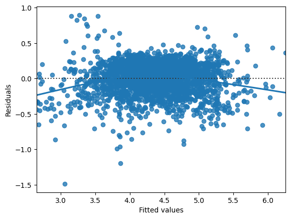

```python
sns.residplot(x="Fitted Values", y="Residuals", data=df_pred, lowess=True)
plt.xlabel("Fitted values")
plt.ylabel("Residuals")
```

**As we can see plot of Residuals vs Fitted values does not follow any pattern so we say the model is linear and Residuals are not dependent**

# TEST FOR NORMALITY

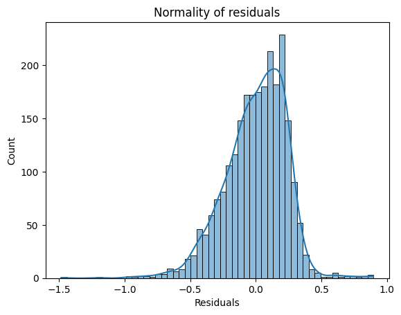

```python
# Histograph for residuals
sns.histplot(df_pred["Residuals"], kde=True)
plt.title("Normality of residuals")
plt.show()
```

The residual seems to be normally distributed.

The QQ plot of residuals can be used to visually check the normality assumption. The normal probability plot of residuals should approximately follow a straight line.

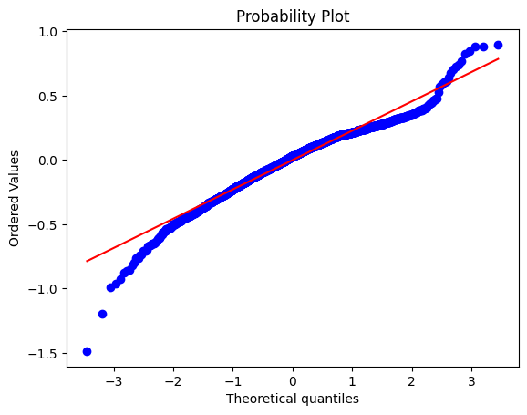

```python
#qq plot
import pylab
import scipy.stats as stats

stats.probplot(df_pred["Residuals"], dist="norm", plot=pylab)
plt.show()
```

Most of the points are on straight line except the points on tails

The Shapiro-Wilk test can also be used for checking the normality. The null and alternate hypotheses of the test are as follows:

Null hypothesis - Data is normally distributed.

Alternate hypothesis - Data is not normally distributed.

```python
# Shapiro test of Normality
stats.shapiro(df_pred["Residuals"])
```

```
ShapiroResult(statistic=0.969292163848877, pvalue=2.4978867831797727e-22)
```

Since p-value < 0.05, the residuals are not normal as per shapiro test.

**Strictly speaking - the residuals are not normal as per the qq plot on the tail ends and shapiro test. It looks close to normal as per histogram plot. However, as an approximation, we might be willing to accept this distribution as close to being normal**

# TEST FOR HOMOSCEDASTICITY

The null and alternate hypotheses of the goldfeldquandt test are as follows:

Null hypothesis : Residuals are homoscedastic

Alternate hypothesis : Residuals have hetroscedasticity

```python
import statsmodels.stats.api as sms
from statsmodels.compat import lzip
```

```python
name = ["F statistic", "p-value"]
test = sms.het_goldfeldquandt(df_pred["Residuals"], X_train)
lzip(name, test)
```

```
[('F statistic', 1.04852631198367), ('p-value', 0.20658754138155935)]
```

**Since p-value > 0.05 we can say that the residuals are homoscedastic**

```python
print(olsres_4.summary())
```

```
                              OLS Regression Results
=================================================================================
Dep. Variable:     normalized_used_price   R-squared:                       0.843
Model:                               OLS   Adj. R-squared:                  0.842
Method:                    Least Squares   F-statistic:                     918.3
Date:                   Tue, 10 Oct 2023   Prob (F-statistic):               0.00
Time:                           01:39:32   Log-Likelihood:                 106.04
No. Observations:                   2417   AIC:                            -182.1
Df Residuals:                       2402   BIC:                            -95.23
Df Model:                             14
Covariance Type:               nonrobust
========================================================================================
                           coef    std err          t      P>|t|      [0.025      0.975]
----------------------------------------------------------------------------------------
const                    1.3799      0.052     26.703      0.000       1.279       1.481
screen_size              0.0254      0.003      7.680      0.000       0.019       0.032
main_camera_mp           0.0207      0.001     15.300      0.000       0.018       0.023
selfie_camera_mp         0.0141      0.001     13.352      0.000       0.012       0.016
ram                      0.0210      0.004      4.734      0.000       0.012       0.030
battery              -1.458e-05   7.12e-06     -2.049      0.041   -2.85e-05   -6.27e-07
weight                   0.0009      0.000      7.156      0.000       0.001       0.001
normalized_new_price     0.4234      0.011     39.191      0.000       0.402       0.445
brand_name_Lenovo        0.0478      0.021      2.223      0.026       0.006       0.090
brand_name_Nokia         0.0652      0.031      2.134      0.033       0.005       0.125
brand_name_Realme        0.1068      0.045      2.352      0.019       0.018       0.196
brand_name_Xiaomi        0.0989      0.026      3.874      0.000       0.049       0.149
os_Others               -0.0669      0.030     -2.243      0.025      -0.125      -0.008
4g_yes                   0.0470      0.015      3.147      0.002       0.018       0.076
no_years_release        -0.0222      0.004     -6.078      0.000      -0.029      -0.015
==============================================================================
Omnibus:                      229.002   Durbin-Watson:                   1.908
Prob(Omnibus):                  0.000   Jarque-Bera (JB):              453.542
Skew:                          -0.617   Prob(JB):                     3.27e-99
Kurtosis:                       4.727   Cond. No.                     3.94e+04
==============================================================================

Notes:
[1] Standard Errors assume that the covariance matrix of the errors is correctly specified.
[2] The condition number is large, 3.94e+04. This might indicate that there are
strong multicollinearity or other numerical problems.
```

```python
# Printing parameteres for the model
olsres_4.params
```

```
const                   1.379943
screen_size             0.025361
main_camera_mp          0.020721
selfie_camera_mp        0.014125
ram                     0.021021
battery                -0.000015
weight                  0.000929
normalized_new_price    0.423390
brand_name_Lenovo       0.047770
brand_name_Nokia        0.065237
brand_name_Realme       0.106810
brand_name_Xiaomi       0.098856
os_Others              -0.066947
4g_yes                  0.047002
no_years_release       -0.022198
dtype: float64
```

```python
# Let us write the equation of linear regression
Equation = "normalize_used_value ="
print(Equation, end=" ")
for i in range(len(X_train.columns)):
    if i == 0:
        print(olsres_4.params[i], "+", end=" ")
    elif i != len(X_train.columns) - 1:
        print(
            olsres_4.params[i],
            "* (",
            X_train.columns[i],
            ")",
            "+",
            end="  ",
        )
    else:
        print(olsres_4.params[i], "* (", X_train.columns[i], ")")
```

[output not shown]

```python
# Evaluating training model performance
score(olsres_4,X_train,y_train,'training')
```

```
Result for the training model are:
```

|  | R_squared | radj_squared | rmse | mae | mape |
| --- | --- | --- | --- | --- | --- |
| 0 | 0.843 | 0.842 | 0.231584 | 0.181572 | 15.014705 |

```python
# Evaluating training model performance
score(olsres_4,X_test,y_test,'testing')
```

```
Result for the testing model are:
```

|  | R_squared | radj_squared | rmse | mae | mape |
| --- | --- | --- | --- | --- | --- |
| 0 | 0.843 | 0.842 | 0.236555 | 0.182573 | 15.518094 |

The model is able to explain 84.2% of the variation in the data

We can see that RMSE on the train and test sets are same. So, our model is not suffering from overfitting.

MAE indicates that our current model is able to predict normalized_used_price within a mean error of 0.18 units on the test data.

Hence, we can conclude the model "olsres_4" is good for prediction as well as inference purposes.

## Actionable Insights and Recommendations

1. The model is able to explain 84.2% of the variation in the data and within 15.5% of the normalized_used_price on the test data, which is good. This indicates that the model is good for prediction as well as inference purposes
2. Normalized used price of the phone is highly dependent on normalized price of new phone so value of normalized new price go up by one units then normalized price of used phone will go up by 0.423 units. They are positively correlated by factor of 0.83.
3. Normalized used price goes up by 0.0253 unit with increase in 1 unit of screen_size, goes up by 0.0207 unit with increase in 1 unit of main_camera_mp,goes up by 0.0141 with increase in 1 unit of selfie_camera_mp and goes up by 0.021021408232354672 with increase in 1 unit of ram. So we can say that screen_size,main_camera_mp, selfie_camera_mp and ram is important feature in deciding the price of the used phone and screen size,main_camera_mp,selfie_camera_mp and ram are in positive correalation with Normlized used price with corr factor more then 0.5
4. Normalized used price of the phone goes up by 0.047 unit if the phone is in 4G network.Normalized_used_price is heigher for phone with 4G about 4.6 euros comapred with phone does not have 4G about 3.9 euros.Similarly it is heigher for phone with 5G network about 5.2 euros comapred with phone does not have 5G about 4.3 euros.Price of a phone with 5G network is heigher then phone with 4g network. There are only 4.4% phones are with 5G network so We still need more data to find correaltion between 5G network and used price of the phone.
5. Almost 93% phone are Andoid based OS in our data and Normalised price of the used phone goes down by 0.07 unit if it based on Other os compared it with Android os phone. As per our data we can conclude that price of phone with Andoid os are heigher then compared with other os. Again we need more data to study effect of other os on price.
6. Normalized used price of phone goes up with the release year means phone with newer release year has more price then older release year. So we can say that release year is also important feature in deciding the price of the used phone and release year is in positive correalation with Normlized used price with corr factor of 0.51.
7. Normalized used price of phone is in negative correaltion with the number of days used for the phone. So if the phone is used for more days then its price will be lesser then compared with phone used for less number of days. Used price of phone is in negative correaltion with days_used with factor of -0.36.
8. Normalized used price of phone is in positive correaltion with battery and weight of the phone with corr factor of 0.61 and 0.38 respectively. As with battery, weight of the phone increases but people still prefer phone with more battery power as they can use phone for longer time without charging.